# WHO WILL PURCHASE AN SUV?

## *WORK SUMMARY*

In this project we’ll apply a Logistic model to a dataset called “SUV Purchase Decision”. This dataset can be found on Kaggle at this link: https://www.kaggle.com/arnabdata/suv-purchase-decision. It has been uploaded and updated by Arnab Dhar who asks to Kaggle’s community to predict who will be a new purchaser of SUV cars. In this analysis we’ll try to accomplish this goal with some regression tools prebuilt in R and some other function created by us.

## *WORK SCHEDULE*

1. **Install and load packages**
2. **Load, Visualize and Summarise the Dataset**
3. **Data Manipulation**
4. **Data Visualization**
5. **Logistic Regression**
6. **Models Validation**
7. **Predictions**

## **INSTALL AND LOAD PACKAGES**

```r
###
## ONLY IF NEEDED
# install.packages("ggplot2")
# install.packages("pscl")
# install.packages("ROCR")
# install.packages("grid")
# install.packages("gridExtra")
###

library(ggplot2)
library(pscl)
library(ROCR)
library(caret)
library(e1071)
library(gridExtra)
library(grid)
```

## **LOAD, VISUALIZE AND SUMMARIZE THE DATASET**

### **LOAD THE DATASET**

As we said in work summary, this dataset is downloadable just using a Kaggle account, for this project we attached it in project folder sent before. First thing first, the reader has to set a working directory to read the file on RStudio, you’ll just have to change the source that you can find on the project folder properties. In our case it will be:

```r
setwd("C:/Users/Utente/Desktop/Sollai-Apicella")
dati.suv <- read.table("SUV_Purchase.csv", header=TRUE, sep=",",
                       dec=".", row.names = "User.ID")
```

## **VISUALIZE THE DATASET**

```r
str(dati.suv)
```

```
'data.frame':   400 obs. of  4 variables:
 $ Gender         : chr  "Male" "Male" "Female" "Female" ...
 $ Age            : int  19 35 26 27 19 27 27 32 25 35 ...
 $ EstimatedSalary: int  19000 20000 43000 57000 76000 58000 84000 150000 33000 65000 ...
 $ Purchased      : int  0 0 0 0 0 0 0 1 0 0 ...
```

```r
head(dati.suv,n=14)
```

```
         Gender Age EstimatedSalary Purchased
15624510   Male  19           19000         0
15810944   Male  35           20000         0
15668575 Female  26           43000         0
15603246 Female  27           57000         0
15804002   Male  19           76000         0
15728773   Male  27           58000         0
15598044 Female  27           84000         0
15694829 Female  32          150000         1
15600575   Male  25           33000         0
15727311 Female  35           65000         0
15570769 Female  26           80000         0
15606274 Female  26           52000         0
15746139   Male  20           86000         0
15704987   Male  32           18000         0
```

## **SUMMARIZE THE DATASET**

```r
summary(dati.suv)
```

```
    Gender               Age        EstimatedSalary    Purchased
 Length:400         Min.   :18.00   Min.   : 15000   Min.   :0.0000
 Class :character   1st Qu.:29.75   1st Qu.: 43000   1st Qu.:0.0000
 Mode  :character   Median :37.00   Median : 70000   Median :0.0000
                    Mean   :37.66   Mean   : 69743   Mean   :0.3575
                    3rd Qu.:46.00   3rd Qu.: 88000   3rd Qu.:1.0000
                    Max.   :60.00   Max.   :150000   Max.   :1.0000
```

As shown, there are not missing values in it in any of our variables, so we can proceed with data manipulation.

## **DATA MANIPULATION**

As we’ve seen in the previous slide, we have some problems about the format of some variables. We’ll manipulate them, forcing them to be factor variable, and we’ll see if these problems will be eliminated.

```r
dati.suv$Purchased <- as.factor(dati.suv$Purchased)
dati.suv$Gender <- as.factor(ifelse(dati.suv$Gender == "Male", 1, 0))
summary(dati.suv)
```

```
 Gender       Age        EstimatedSalary  Purchased
 0:204   Min.   :18.00   Min.   : 15000   0:257
 1:196   1st Qu.:29.75   1st Qu.: 43000   1:143
         Median :37.00   Median : 70000
         Mean   :37.66   Mean   : 69743
         3rd Qu.:46.00   3rd Qu.: 88000
         Max.   :60.00   Max.   :150000
```

## **DATA VISUALIZATION**

### *Salaries Boxplot against Purchase of an SUV*

We indicate with the red boxplot the customers who have not bought. They have a lower median than the customers who have bought, indicated in blue.

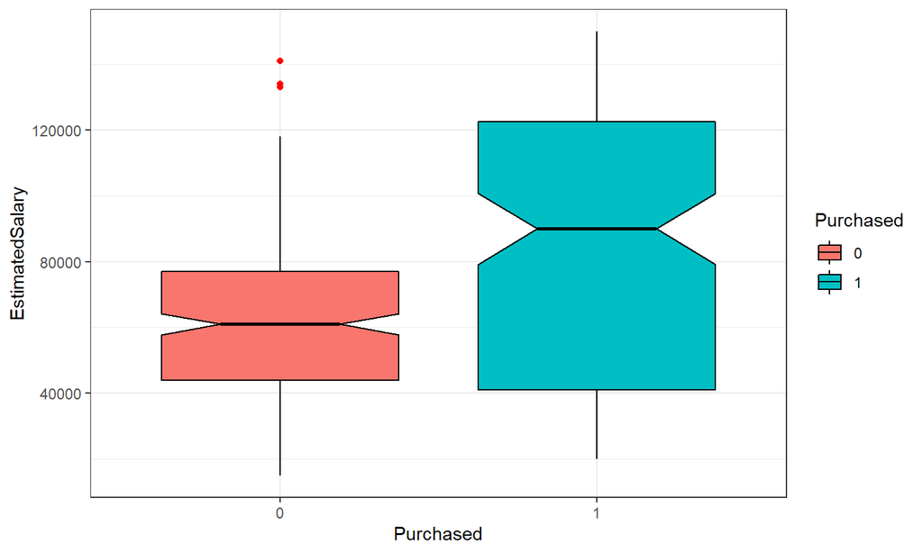

### *Age’s Boxplot against Purchase of an SUV*

We have similar results with the age’s boxplot

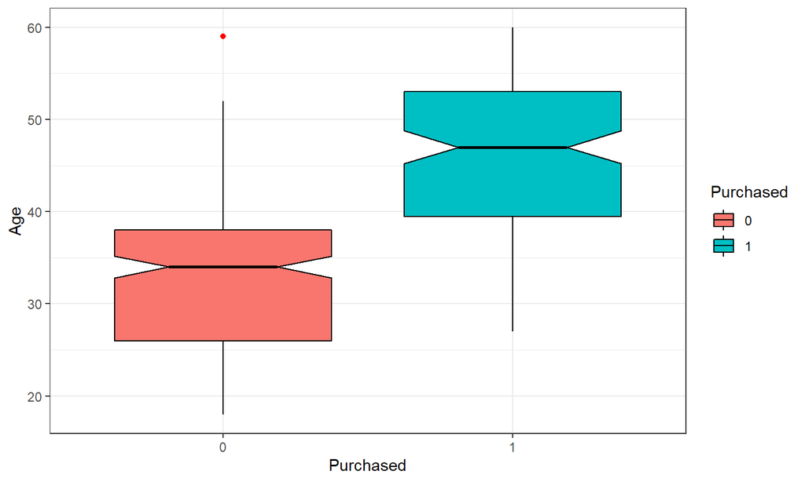

### *Histogram of Age variable against Purchase of an SUV*

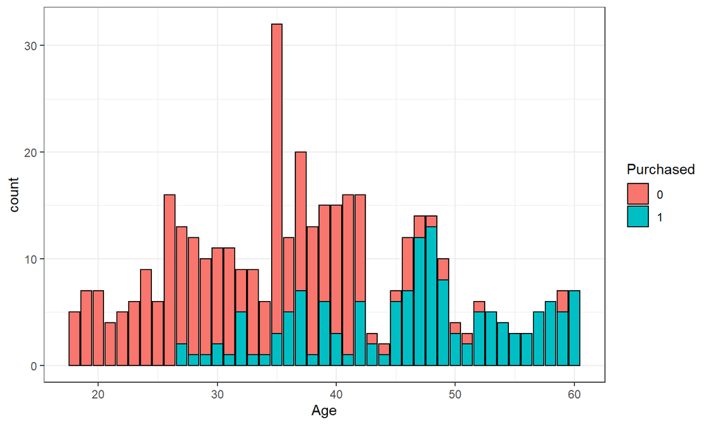

### *Histogram of Salaries against Purchase of an SUV*

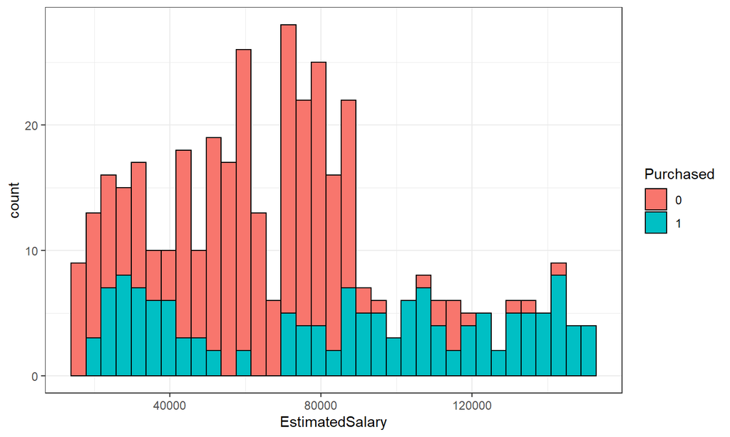

### *Genders Barplot by Purchase an SUV*

The barplot indicates in red the customers who have not bought and in blue those who have bought. We remember that males were indicated with 1 and the females with 0. As shown, there are not relevant differences between the two genders.

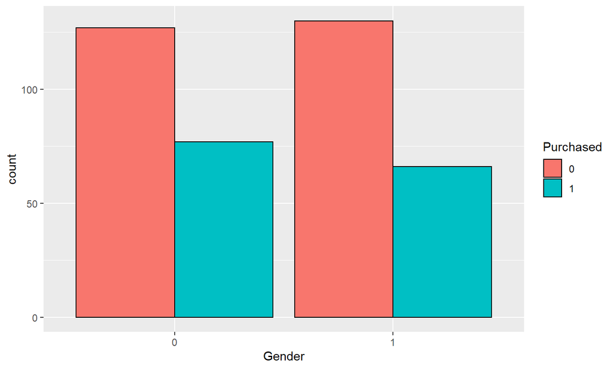

## **LOGISTIC REGRESSION**

### **Classification**

We split our dataset to train our model, creating a test set and a validation set. We choose a 70:30 proportion. We then setted a seed in order to have same results even if running code on different computers.

```r
n <- nrow(dati.suv)
set.seed(4)
tot.suv <- sample(1:n,floor(0.7*n))
est.suv <- dati.suv[tot.suv,]
val.suv <- dati.suv[-tot.suv,]
summary(est.suv)
```

```
 Gender       Age        EstimatedSalary  Purchased
 0:147   Min.   :18.00   Min.   : 15000   0:174
 1:133   1st Qu.:30.00   1st Qu.: 42750   1:106
         Median :37.00   Median : 65000
         Mean   :38.06   Mean   : 69196
         3rd Qu.:46.00   3rd Qu.: 88000
         Max.   :60.00   Max.   :150000
```

### *Model estimation*

```r
glm.suv <- glm(Purchased ~ Gender + EstimatedSalary + Age,
               family=binomial, data=est.suv)
summary(glm.suv)
```

```
Call:
glm(formula = Purchased ~ Gender + EstimatedSalary + Age, family = binomial,
    data = est.suv)

Deviance Residuals:
    Min       1Q   Median       3Q      Max
-3.0885  -0.5201  -0.1304   0.3274   2.3725

Coefficients:
                  Estimate Std. Error z value Pr(>|z|)
(Intercept)     -1.341e+01  1.724e+00  -7.780 7.25e-15 ***
Gender1          3.478e-01  3.696e-01   0.941    0.347
EstimatedSalary  4.139e-05  7.034e-06   5.883 4.02e-09 ***
Age              2.475e-01  3.335e-02   7.422 1.16e-13 ***
---
Signif. codes:  0 '***' 0.001 '**' 0.01 '*' 0.05 '.' 0.1 ' ' 1

(Dispersion parameter for binomial family taken to be 1)

    Null deviance: 371.48  on 279  degrees of freedom
Residual deviance: 188.37  on 276  degrees of freedom
AIC: 196.37

Number of Fisher Scoring iterations: 6
```

As we can see from the summary, the gender variable is not significantly different from 0.

### *Model Validation*

```r
anova(glm.suv, test="Chisq")
```

```
Analysis of Deviance Table

Model: binomial, link: logit

Response: Purchased

Terms added sequentially (first to last)

                Df Deviance Resid. Df Resid. Dev  Pr(>Chi)
NULL                              279     371.48
Gender           1    1.154       278     370.33    0.2827
EstimatedSalary  1   45.248       277     325.08 1.736e-11 ***
Age              1  136.710       276     188.37 < 2.2e-16 ***
---
Signif. codes:  0 '***' 0.001 '**' 0.01 '*' 0.05 '.' 0.1 ' ' 1
```

**anova()** sequentially compares the smaller model to the next more complex model by adding a variable in each step.

```r
pR2(glm.suv)
```

```
fitting null model for pseudo-r2
```

```
         llh      llhNull           G2     McFadden         r2ML         r2CU
 -94.1849473 -185.7409228  183.1119510    0.4929230    0.4800233    0.6534004
```

After these analysis, we’ll eliminate the Gender variable for the next model, using backward elimination process for variable selection.

### *New Model Estimation*

```r
glm.suv2<-glm(Purchased ~ EstimatedSalary + Age,
              family=binomial, data=est.suv)
summary(glm.suv2)
```

```
Call:
glm(formula = Purchased ~ EstimatedSalary + Age, family = binomial,
    data = est.suv)

Deviance Residuals:
    Min       1Q   Median       3Q      Max
-3.1193  -0.5487  -0.1319   0.3555   2.2872

Coefficients:
                  Estimate Std. Error z value Pr(>|z|)
(Intercept)     -1.303e+01  1.647e+00  -7.912 2.52e-15 ***
EstimatedSalary  4.075e-05  7.004e-06   5.818 5.95e-09 ***
Age              2.437e-01  3.271e-02   7.450 9.36e-14 ***
---
Signif. codes:  0 '***' 0.001 '**' 0.01 '*' 0.05 '.' 0.1 ' ' 1

(Dispersion parameter for binomial family taken to be 1)

    Null deviance: 371.48  on 279  degrees of freedom
Residual deviance: 189.26  on 277  degrees of freedom
AIC: 195.26

Number of Fisher Scoring iterations: 6
```

In this new model, all of the coefficients are significantly different from 0. AIC is a little bit smaller and this could be expected since we eliminated a parameter. We’ll see with Model Validation if this will be appropriate for previsions.

### *New Model Validation*

```r
anova(glm.suv2, test="Chisq")
```

```
Analysis of Deviance Table

Model: binomial, link: logit

Response: Purchased

Terms added sequentially (first to last)

                Df Deviance Resid. Df Resid. Dev  Pr(>Chi)
NULL                              279     371.48
EstimatedSalary  1    46.25       278     325.23 1.041e-11 ***
Age              1   135.97       277     189.26 < 2.2e-16 ***
---
Signif. codes:  0 '***' 0.001 '**' 0.01 '*' 0.05 '.' 0.1 ' ' 1
```

```r
pR2(glm.suv2)
```

```
fitting null model for pseudo-r2
```

```
         llh      llhNull           G2     McFadden         r2ML         r2CU
 -94.6323078 -185.7409228  182.2172300    0.4905145    0.4783591    0.6511351
```

### *Coefficient Interpretation*

```r
coef(glm.suv2)
```

```
    (Intercept) EstimatedSalary             Age
  -1.303100e+01    4.075174e-05    2.436744e-01
```

We know, from logit’s theory, that these coefficients don’t represent each variable’s impact on probabilities! They represent, instead, the impact on a transformation: the logarithm of the odds. Both variables have a positive effect on logit. We can transform coefficients from logit to odds to read them in an easier way:

```r
odds.coef <- exp(coef(glm.suv2))[-1]
odds.coef
```

```
EstimatedSalary             Age
       1.000041        1.275929
```

In the Predictions Section we’ll see which are, instead, the probabilities to have a better view on how our model estimate them.

### *Fitting Results and Printing the Accuracy*

```r
fitted.results <- predict(glm.suv2,newdata=val.suv,type='response')
fitted.results <- ifelse(fitted.results > 0.5,1,0)
claserror <- mean(fitted.results !=val.suv$Purchased)
print(paste('Accuracy',1-claserror))
```

```
[1] "Accuracy 0.841666666666667"
```

### *Receiver Operating Characteristic*

```r
p <- predict(glm.suv2,newdata=val.suv,type='response')
pr <- prediction(p, val.suv$Purchased)
auc <- performance(pr, measure = "auc")
auc <- auc@y.values[[1]]
auc
```

```
[1] 0.9169652
```

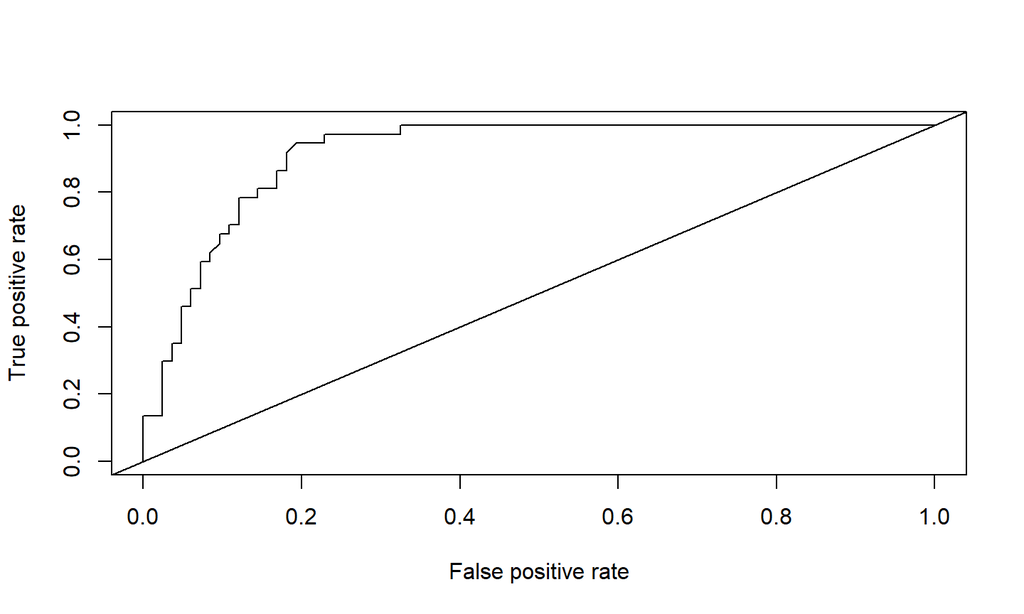

```r
prf <- performance(pr, measure = "tpr", x.measure = "fpr")
plot(prf)
abline(0,1)
```

### *Confusion Matrix*

```r
confusionMatrix(fitted.results, val.suv$Purchased)
```

```
Confusion Matrix and Statistics

          Reference
Prediction  0  1
         0 71  7
         1 12 30

               Accuracy : 0.8417
                 95% CI : (0.7638, 0.9019)
    No Information Rate : 0.6917
    P-Value [Acc > NIR] : 0.0001288

                  Kappa : 0.6422

 Mcnemar's Test P-Value : 0.3587954

            Sensitivity : 0.8554
            Specificity : 0.8108
         Pos Pred Value : 0.9103
         Neg Pred Value : 0.7143
             Prevalence : 0.6917
         Detection Rate : 0.5917
   Detection Prevalence : 0.6500
      Balanced Accuracy : 0.8331

       'Positive' Class : 0
```

We can see from this output how our model is working. We can see that 71 times predicted a 0 when it was really 0. It predicted then 30 times 1 in correct way. Instead it predicted a 0 when in reality the result was 1 seven times, producing a small number of type 2 error. It produced 12 type 1 error too because it predicted a purchase but there was a reject in reality.

## **PREDICTIONS**

```r
newdata <- data.frame(Age = sample(dati.suv$Age, 20), Salary = sample(dati.suv$EstimatedSalary, 20))
Probability <- vector(mode = "numeric", length = 20)
for(i in 1:20){
  Probability[i] <- f.pre(newdata$Age[i], newdata$Salary[i])
  tab <- cbind(newdata, Probability)
}
tab
```

```
   Age Salary  Probability
1   52  47000 0.8256923353
2   35  64000 0.1307566838
3   48  75000 0.8483542888
4   47  33000 0.4418897757
5   37  39000 0.0812316165
6   42  79000 0.6041320186
7   22  86000 0.0152844965
8   30  58000 0.0336612454
9   18  41000 0.0009349898
10  19 107000 0.0172804081
11  43  72000 0.5941442179
12  46  15000 0.2295769200
13  36  90000 0.3563904675
14  45  74000 0.7211104453
15  48  41000 0.5832652907
16  60  38000 0.9584344638
17  36  23000 0.0348432287
18  26  22000 0.0030216458
19  29  48000 0.0178391601
20  43  32000 0.2228827624
```

### *Predictions on different types of customer*

We created then a double way table that shows us what is the probability of purchasing an SUV for a specific customer within a certain income class and a certain range of age. We can now have some other information about the probabilities distribution over these two variables.

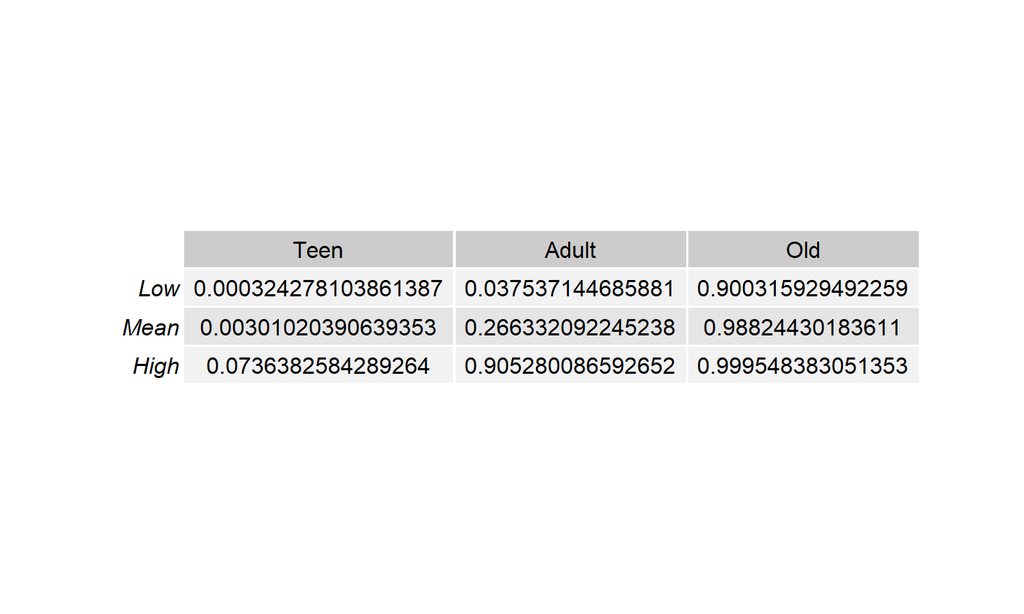

```r
tt <- ttheme_default(colhead=list(fg_params = list(parse=TRUE))) #setting the theme for the table
grid.table(tab.prob, theme=tt)
```

Many conclusions can be assumed about this table. The case with the highest probability is the one of the **old customer** with an **high salary**. The salary is not very influential in the case of the **young customer**. The reason for which we assume this is that young people have poor driving experience, so they buy cars that are easier to drive. For the customer who has an **average age**, the probability of buying the SUV instead depends a lot on the salary. The customer with an **average age and average salary** has the 26% of probability to buy the SUV but this increase a lot when age or salary increase.